# Homework I

Kozubek Hubert

30 03 2022

# Installing the necessary packages

#Preparation

For this project data used in it came from a “worldfootballR” package. For the simplicity of usage data was scraped and saved into “EPL_2021.csv”. Inside csv file we have data about football and the goal is to classify if the Goal was scored.

```r
#setwd("D:\\Hubert\\Dokumenty\\Politechnika Warszawska\\IIAD\\Semestr IV\\Warsztaty Badawcze\\Prace Domowe")
shot_location <- read.csv("EPL_2021.csv") #reading data from csv file
head(shot_location)
```

```
##   league     id minute      result     X     Y         xG       player h_a
## 1    EPL 425564     10 MissedShots 0.913 0.539 0.05346401 Frank Onyeka   h
## 2    EPL 425565     11  ShotOnPost 0.908 0.315 0.11829661 Bryan Mbeumo   h
## 3    EPL 425567     21        Goal 0.874 0.698 0.05214472  Sergi Canos   h
## 4    EPL 425568     27 MissedShots 0.812 0.478 0.06570620  Sergi Canos   h
## 5    EPL 425569     29 MissedShots 0.892 0.357 0.08069062 Bryan Mbeumo   h
## 6    EPL 425579     65   SavedShot 0.882 0.332 0.07258376  Sergi Canos   h
##   player_id situation season  shotType match_id home_team away_team home_goals
## 1      9681  OpenPlay   2021      Head    16376 Brentford   Arsenal          2
## 2      6552  OpenPlay   2021 RightFoot    16376 Brentford   Arsenal          2
## 3      1078  OpenPlay   2021 RightFoot    16376 Brentford   Arsenal          2
## 4      1078  OpenPlay   2021 RightFoot    16376 Brentford   Arsenal          2
## 5      6552  OpenPlay   2021 RightFoot    16376 Brentford   Arsenal          2
## 6      1078  OpenPlay   2021 RightFoot    16376 Brentford   Arsenal          2
##   away_goals                date player_assisted   lastAction
## 1          0 2021-08-13 19:00:00            <NA>       Aerial
## 2          0 2021-08-13 19:00:00      Ivan Toney  Throughball
## 3          0 2021-08-13 19:00:00   Ethan Pinnock BallRecovery
## 4          0 2021-08-13 19:00:00    Frank Onyeka         Pass
## 5          0 2021-08-13 19:00:00 Kristoffer Ajer      Chipped
## 6          0 2021-08-13 19:00:00    Bryan Mbeumo         Pass
```

First thing we do is to preprocess data to make it easier for later model creation

```r
shot_stats <- shot_location %>% filter(result != "OwnGoal") %>% # filtering own goals
  mutate(status = ifelse(result == "Goal", "1", "0")) %>% # making problem a binary classification
  mutate(distanceToGoal = sqrt((105 - (X * 105)) ^ 2 + (32.5 - (Y * 68)) ^ 2)) %>% # creating new feature, distance to goal
  mutate(angleToGoal = abs(atan((7.32 * (105 - (X * 105))) / ((105 - (X * 105))^2 + (32.5 - (Y * 68)) ^ 2 - (7.32 / 2) ^ 2)) * 180 / pi)) %>% #creating new feature, angle to goal
  mutate(status = factor(status),
         h_a = factor(h_a),
         situation = factor(situation),
         shotType = factor(shotType),
         lastAction = factor(lastAction),
         minute = as.numeric(minute)) %>%
  select(status, minute, h_a, situation, shotType, lastAction, distanceToGoal, angleToGoal)
shot_stats$status->f
as.numeric(levels(f))[f] -> n
shot_stats$status = n
```

Splitting data into training and testing set

```r
set.seed(123)
# create the sample row index for train and test set
index <- createDataPartition(shot_stats$status, p = 0.8, list = FALSE)

# using index split to data to train and test set
train <- shot_stats[index,]
test  <- shot_stats[-index,]
```

Checking aproximatly how many 1’s are in dataset

```r
shot_stats$status->n
sum(n)/length(n)
```

```
## [1] 0.1048771
```

Now that we have our data prepared, we can proceed to training our model

# Model evaluation

For the model random forest was chosen

```r
set.seed(123)
ranger_model <- ranger(status ~., data = train)
```

## Chosing observation

```r
obs <-  test[7,]
```

## Making prediction

```r
p <- predict(ranger_model, obs)
p$predictions
```

```
## [1] 0.07432728
```

```r
obs$status
```

```
## [1] 0
```

As we can see model made quiet good prediction for this observation. Model confidence, that the observation is 0, is about 93%.

# Break Down

```r
explainer_rf <- DALEX::explain(ranger_model,
                               data = test[,-1],
                               y = test$status,
                               label = "random forest")
```

```
## Preparation of a new explainer is initiated
##   -> model label       :  random forest
##   -> data              :  1472  rows  7  cols
##   -> target variable   :  1472  values
##   -> predict function  :  yhat.ranger  will be used (  default  )
##   -> predicted values  :  No value for predict function target column. (  default  )
##   -> model_info        :  package ranger , ver. 0.13.1 , task regression (  default  )
##   -> predicted values  :  numerical, min =  0.001179986 , mean =  0.1129464 , max =  0.9463487
##   -> residual function :  difference between y and yhat (  default  )
##   -> residuals         :  numerical, min =  -0.8843219 , mean =  -0.01104426 , max =  0.9971796
##   A new explainer has been created!
```

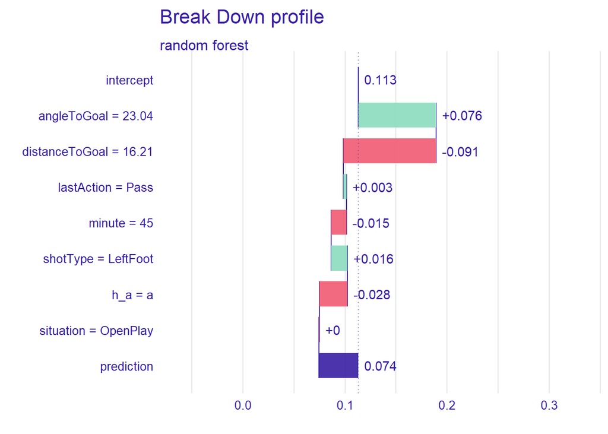

```r
class(obs$status) = "Numeric"
bd_pr <- predict_parts(explainer = explainer_rf,
                       new_observation = obs,
                       type = "break_down")
plot(bd_pr)
```

According to the Break Down variables distance to goal and angle to goal have the biggest impact on the predicted value. Distance to goal 16.21 decrees prediction by 0,091, on the contrary angle to goal equal to 23.04 increases prediction by 0,076.

# Sapley

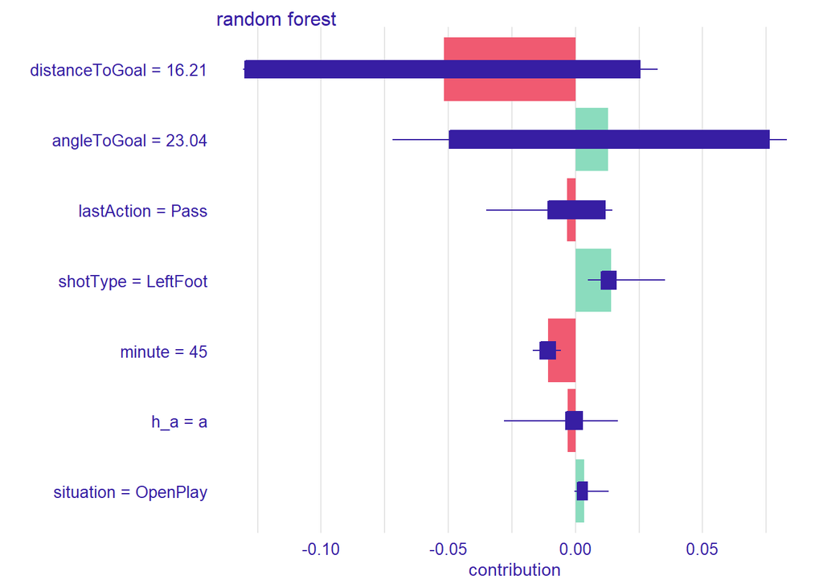

```r
shap_pr <- predict_parts(explainer = explainer_rf,
                         new_observation = obs,
                         type = "shap")
plot(shap_pr)
```

As we can see both distance to goal and angle to goal have biggest influence on the prediction. We can notice that a lot of variables can have both positive and negative influence on the prediction.

# Different effects

```r
test %>%
  filter(distanceToGoal < 20, angleToGoal < 10) %>%
  slice(1) -> obs2
```

```r
p <- predict(ranger_model, obs2)
p$predictions
```

```
## [1] 0.05641544
```

```r
obs2$status
```

```
## [1] 1
```

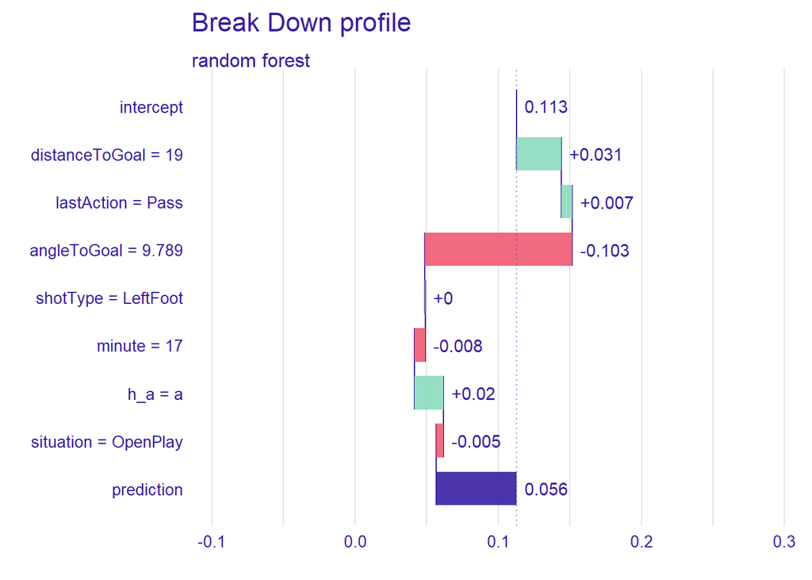

```r
class(obs$status) = "Numeric"
bd_pr <- predict_parts(explainer = explainer_rf,
                       new_observation = obs2,
                       type = "break_down")
plot(bd_pr)
```

As we can see from the break down plot, variable distance to goal has a positive impact on prediction for new observation opposite to impact that the same variable had on observation 1. Same is with the varible angle to goal. This time model predicted 0 with a 94% confidence and it turned out to be wrong.

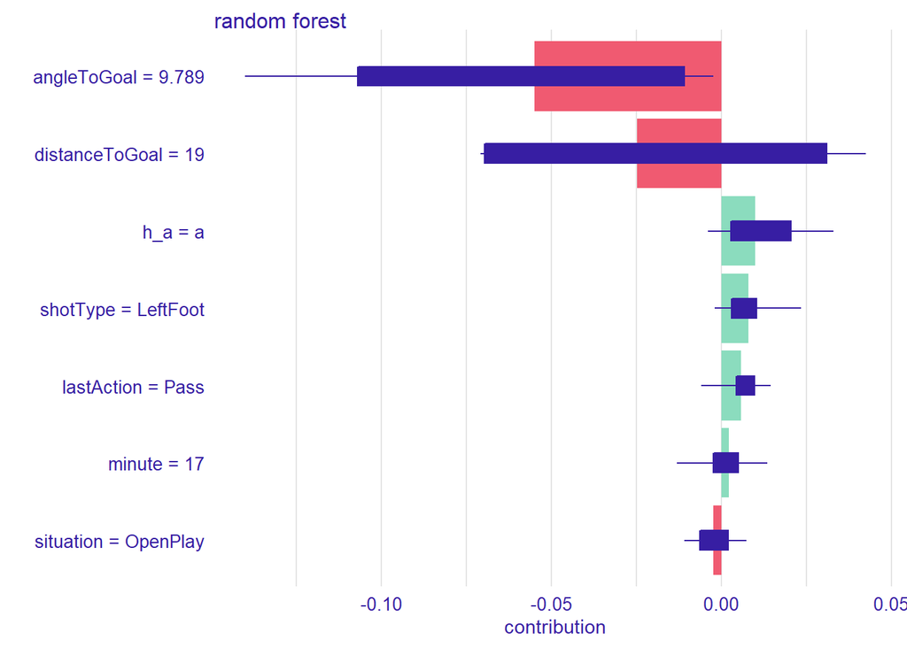

```r
shap_pr <- predict_parts(explainer = explainer_rf,
                         new_observation = obs2,
                         type = "shap")
plot(shap_pr)
```

# Summary Looking at the shapely value plot for observation 1 distance to goal has biggest influence for the prediction, followed right after we have angle to goal. On the other hand in the second observation angle to goal have bigger influence on the prediction than the distance to goal. Also in the observation 1 angle to goal has a positive impact on the prediction while in the second observation impact is negative. We can also see that other variables don’t have the same order in terms of impact on the prediction.

For both observations variables distance to goal and angle to goal have biggest influence. Looking at boxplots on Sapley plot we can see that even slightly changing those variables we can influence prediction the most.